# PML Project Writeup

Jason Liggett

11/22/2015

## Executive Summary

Build a machine learning algorithm to predict activity quality from from the [Weight Lifting Exercises Dataset](http://groupware.les.inf.puc-rio.br/har).

Brief summary of the dataset: >Six young health participants were asked to perform one set of 10 repetitions of the >Unilateral Dumbbell Biceps Curl in five different fashions: exactly according to the >specification (Class A), throwing the elbows to the front (Class B), lifting the >dumbbell only halfway (Class C), lowering the dumbbell only halfway (Class D) and >throwing the hips to the front (Class E).<sup>1</sup>

## Prepare for the Analysis

Obtain the essential R libraries.

```r
## packages used
install.packages("RCurl")
install.packages("caret")
install.packages("rattle", dependencies=TRUE)
```

```r
# get libraries needed for the analysis
library(RCurl)
library(caret)
library(rattle)
```

## Get the Data

The training and test data used are available at the following URLs:

- Training data located at https://d396qusza40orc.cloudfront.net/predmachlearn/pml-training.csv
- Test set located at https://d396qusza40orc.cloudfront.net/predmachlearn/pml-testing.csv

```r
# read csv data
trainingURL <- "http://d396qusza40orc.cloudfront.net/predmachlearn/pml-training.csv"
testURL <- "http://d396qusza40orc.cloudfront.net/predmachlearn/pml-testing.csv"
training <- read.csv(trainingURL,header = TRUE, na.strings = c("NA", ""))
test <- read.csv(testURL,header = TRUE, na.strings = c("NA", ""))
```

## Clean the Data

Just a few steps to clean the data. First, remove the non-relevant columns: X, user_name, new_window, num_window, and all timestamp variables.

```r
# remove non relevant variables
training <- training[,!grepl("X|user_name|timestamp|new_window|num_window",colnames(training))]
test <- test[,!grepl("X|user_name|timestamp|new_window|num_window",colnames(test))]
```

Second, quite a few of the variables in the dataset contain too many NA values. Remove those variables.

```r
# remove variables with too many NA values
training <- training[, (colSums(is.na(training)) == 0)]
test <- test[, (colSums(is.na(test)) == 0)]
```

Finally, variables that have no variability are not useful when constructing a prediction model<sup>2</sup>. If they exist, let’s get rid of them.

```r
# some variables have no variability at all and are not useful for constructing the prediction model
zeroVarTrain <- nearZeroVar(training,saveMetrics=TRUE)
training <- training[, zeroVarTrain[,'nzv']==0]
zeroVarTest <- nearZeroVar(test,saveMetrics=TRUE)
test <- test[, zeroVarTest[,'nzv']==0]
```

Check the size of the training and test sets to confirm they are the same size.

```r
# confirm number of variables in each set is equal
dim(training);dim(test)
```

```
## [1] 19622    53
```

```
## [1] 20 53
```

## Create Training Sets

70% of the training data will be used to build the model. The remaining 30% will be used to validate the accuracy of the model’s prediction.

```r
# create training and validation sets from training data
set.seed(1234)
inTrain = createDataPartition(y = training$classe, p = 0.7, list = FALSE)
subtrain = training[inTrain,]
validation = training[-inTrain,]
```

## Create the Model

The random forest prediction model was chosen because it is one of the most used/accurate algorithms<sup>2</sup> and works well with a dataset that contains many variables.

```r
# random forest
modelFit2 <- train(classe ~., method="rf", data=subtrain, importance=TRUE,
                  trControl = trainControl(method = "cv", number = 3))
print(modelFit2$finalModel)
```

```
##
## Call:
##  randomForest(x = x, y = y, mtry = param$mtry, importance = TRUE)
##                Type of random forest: classification
##                      Number of trees: 500
## No. of variables tried at each split: 27
##
##         OOB estimate of  error rate: 0.6%
## Confusion matrix:
##      A    B    C    D    E class.error
## A 3902    3    0    0    1 0.001024066
## B   22 2630    6    0    0 0.010534236
## C    0    9 2381    6    0 0.006260434
## D    0    0   24 2227    1 0.011101243
## E    0    0    3    7 2515 0.003960396
```

The model appears to have worked as intended. The OOB error rate and confusion matrix illustrate a high rate of accuracy for our model. The following Variable Importance Plot shows which variables of the training dataset have the greatest importance of the model.

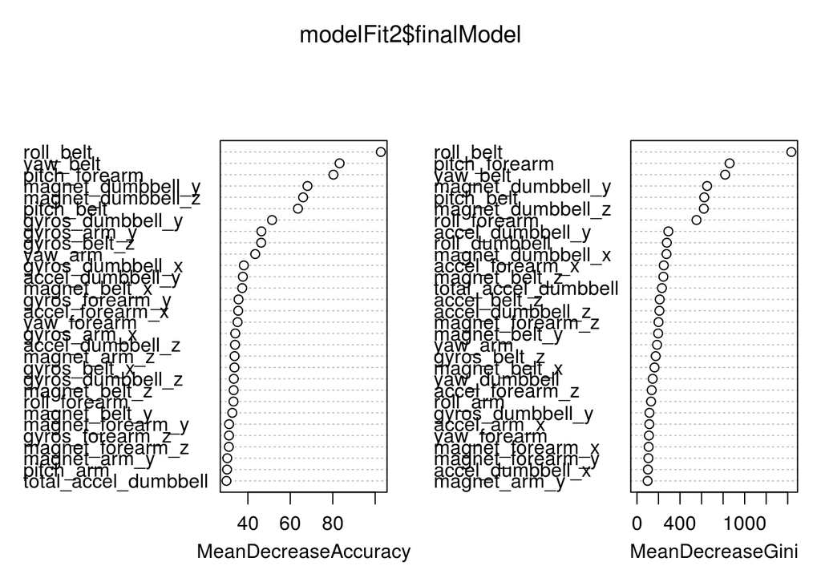

## Cross Validation

Run the prediction model against the validation data.

```r
# run random forrest model on validation set to check accuracy
set.seed(4321)
pmodel2 <- predict(modelFit2,validation)
confus <- confusionMatrix(validation$classe, pmodel2)
confus$table
```

```
##           Reference
## Prediction    A    B    C    D    E
##          A 1674    0    0    0    0
##          B   11 1127    1    0    0
##          C    0    4 1018    4    0
##          D    0    1    6  956    1
##          E    0    1    2    3 1076
```

```r
# error rate for validation data
predMatrix = with(validation,table(pmodel2,classe))
sum(diag(predMatrix))/sum(as.vector(predMatrix))
```

```
## [1] 0.9942226
```

## Run the Prediction Model on Test Dataset

The test dataset consisted of 20 rows. These are the predicted `classe` variable for the 20 rows.

```r
# prediction output of test data
print(predict(modelFit2,test))
```

```
##  [1] B A B A A E D B A A B C B A E E A B B B
## Levels: A B C D E
```

## Create Test Script Files for Project Submission

```r
# create test script files for project submission
answers = predict(modelFit2,test)
pml_write_files = function(x){
  n = length(x)
  for(i in 1:n){
    filename = paste0("problem_id_",i,".txt")
    write.table(x[i],file=filename,quote=FALSE,row.names=FALSE,col.names=FALSE)
  }
}
pml_write_files(answers)
```

# References

1. Velloso, E.; Bulling, A.; Gellersen, H.; Ugulino, W.; Fuks, H. Qualitative Activity Recognition of Weight Lifting Exercises. Proceedings of 4th International Conference in Cooperation with SIGCHI (Augmented Human ’13) . Stuttgart, Germany: ACM SIGCHI, 2013.
2. http://sux13.github.io/DataScienceSpCourseNotes/8_PREDMACHLEARN/Practical_Machine_Learning_Course_Notes.html